# Лабораторная работа № 4

Дискреционное разграничение прав в Linux. Расширенные атрибуты

Морозов М. Е.

Российский университет дружбы народов, Москва, Россия

27 сентября 2024

## Цель работы

Получение практических навыков работы в консоли с расширенными атрибутами файлов.

## Теоретическое введение

chattr — команда, изменяющая атрибуты файлов на файловых системах ext2fs, ext3, ext4 и частично на других файловых системах Linux. Операторы - “+” обозначает добавление указанных атрибутов к существующим - “-” обозначает их снятие - “=” обозначает установку только этих атрибутов файлам.

Символы “ASacDdijsu” указывают на новые атрибуты файлов.

# Выполнение лабораторной работы

## Попробуем добавить атрибут к файлу от имени записи guest.

Получаем ошибку, поэтому делаем это от имени администратора

## Посмотрим сработала ли команда.

К файлу добавился атбрибут “a”

## Попробуем различные действия с этим файлом.

Сработала только команда чтения

## Пробуем дальше.

Несмотря на то, что владелец файла может читать и редактировать его по модификаторам доступа, мы не можем менять его как хотим

## Теперь снимем атрибут “a” и поставим “i”.

Меняем атрибуты

# Результаты работы команд

## 1 (рис. [-@fig:001])

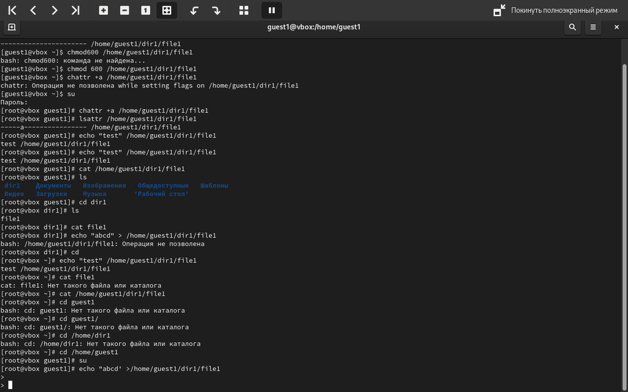

1

## 2 (рис. [-@fig:002])

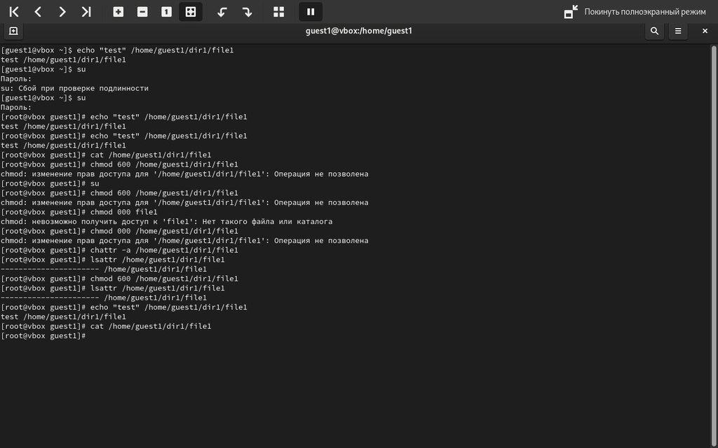

2

## 3 (рис. [-@fig:003])

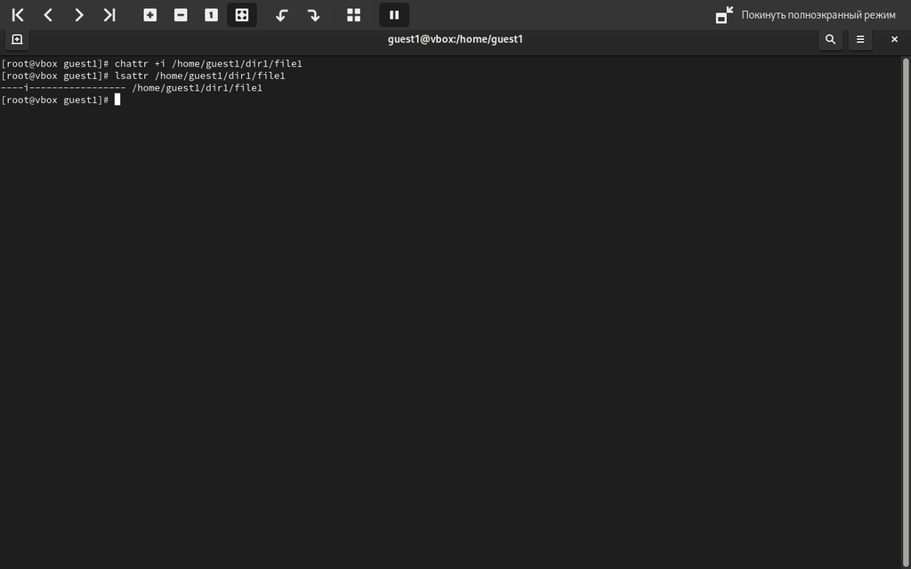

3

## Выводы

Получили практических навыков работы в консоли с расширенными атрибутами файлов.

## Список литературы

1. chattr [Электронный ресурс]. Wikimedia Foundation, Inc., 2024. URL: https://en.wikipedia.org/wiki/Chattr.